# Resumen de métodos multivariados

La clave del uso de los métodos multivariados está en:

- El tipo de problema para el cuál el método está propuesto.
- El objetivo de cada técnica.
- La estructura de datos requerida para utilizar cada técnica.
- El muestreo realizado para cada técnica.
- Entender el concepto subyacentes a cada técnica.

## Clasificación de técnicas

- Modelo:
  $$y_1 + y_2 + \cdots + y_i$$
- Técnicas:
  - Ordenación no restringida.
  - Análisis aglomerativo (cluter analisis).
- Modelo:
  $$y_1 + y_2 + \cdots + y_i = x$$
- Técnicas:
  - Anova multivariado (MANOVA).
  - Prueba de Mantel.
  - Análisis discriminante.
  - Regresión logística.
  - Árboles de clasifiación.
- Modelo:
  $$y_1 + y_2 + \cdots + y_i = x_1 + x_2 + \cdots + x_j$$
- Técnicas:
  - Ordenación con restricción.
  - Correlación Canónico.
  - Árboles de regresión multivariados.

## Ordenación sin restricción:

- PCA (Componentes principales)
- MDS o PCoA (Escalamiento multidimensional métrico)
- CA (Análsis de correspondencia)
- DCA (Análisis de correspondencia segmentado o análisis de correspodencia sin tendencia)
- NMDS (Escalamiento multidimensional no-métrico)

Objetivo: Estraer gradientes de máxima variación.

## Análisis aglomerativo (cluster):

- Varias ténicas, jerárquicas, divisivas, etc.

Objetivo: Establecer grupos de entes similares.

## Discriminación:

- MANOVA (Anova multivariado)
- ANOSIM (Análisis de similitud)
- Mantel (Prueba de Mantel)
- LR (Regresión logística)
- DA (Análisis discriminante)

Objetivo: Prueba para diferenciar entre grupos de entidades y predecir la pertenencia a un grupo.

## Ordenación con restricción;

- RDA (Análisis de redundancia)
- CCA (Análisis de correspondencia canónico)

Objetivo: Extraer gradientes de variación en variables dependientes explicadas por variables independientes.

## Escalamiento multidimensional o Análisis de Coordenadas Principales.

### MDS o PCoA

```r
peces <- read.csv2("peces.csv", row.names = 1)
sumEsp  <- apply(peces,1,sum)
peces   <- peces[sumEsp!=0,]
require(vegan)
peces.perfil <- decostand(peces, method = "total")
mat_dist <- dist(peces.perfil, method = "manhattan")
print(mat_dist)
```

```
           1         2         3         4         5         6         7         9        10        11
2  1.1666667
3  1.3750000 0.2500000
4  1.6190476 0.6666667 0.5416667
5  1.8823529 1.5882353 1.4632353 0.9215686
6  1.7142857 0.8571429 0.7619048 0.3809524 0.8179272
7  1.3750000 0.3750000 0.2500000 0.5714286 1.3455882 0.6369048
9  2.0000000 1.4285714 1.4285714 1.2380952 1.1848739 1.0000000 1.3035714
10 1.8571429 0.7857143 0.7142857 0.7142857 1.0672269 0.6190476 0.5357143 1.1428571
11 1.4545455 0.6060606 0.6477273 0.8658009 1.4705882 0.9696970 0.6477273 1.4935065 0.9220779
12 1.4444444 0.5555556 0.5555556 0.6349206 1.4771242 0.7777778 0.4444444 1.3174603 0.8571429 0.3535354
13 1.4736842 0.7368421 0.7368421 0.9323308 1.5882353 1.1228070 0.7631579 1.6466165 1.1203008 0.4019139
14 1.6428571 1.0000000 0.9285714 0.7857143 1.3739496 0.8571429 0.9285714 1.5000000 1.0714286 0.6688312
15 1.7575758 1.2121212 1.2121212 0.9610390 1.1105169 0.7792208 0.9621212 1.3116883 0.8268398 0.8484848
16 1.8500000 1.4500000 1.4000000 1.1095238 0.9647059 0.9595238 1.2250000 1.4071429 1.0071429 1.3181818
17 1.9090909 1.5454545 1.5000000 1.2272727 1.0695187 1.0411255 1.3295455 1.4480519 1.2727273 1.3636364
18 1.9523810 1.6666667 1.6190476 1.2380952 1.0504202 1.0476190 1.4464286 1.4285714 1.3333333 1.4285714
19 2.0000000 1.6521739 1.6086957 1.3395445 1.0690537 1.1573499 1.5217391 1.3043478 1.3788820 1.6442688
20 2.0000000 1.8928571 1.8214286 1.4642857 1.0609244 1.2380952 1.7142857 1.4642857 1.5714286 1.7857143
21 2.0000000 1.9354839 1.8387097 1.4869432 1.1404175 1.2964670 1.8064516 1.5806452 1.6635945 1.8709677
22 2.0000000 1.9722222 1.8888889 1.4920635 1.1601307 1.2976190 1.7777778 1.6111111 1.6388889 1.8611111
23 2.0000000 2.0000000 2.0000000 1.9047619 1.5882353 1.7142857 1.8750000 1.0000000 1.7142857 1.8181818
24 2.0000000 2.0000000 2.0000000 1.8095238 1.4980392 1.6190476 1.8750000 1.4666667 1.6000000 1.8181818
25 2.0000000 2.0000000 1.8750000 1.6277056 1.1016043 1.4372294 1.7500000 1.6363636 1.4935065 1.8181818
26 2.0000000 1.9534884 1.8604651 1.5304540 1.1846785 1.3444075 1.8139535 1.5348837 1.6744186 1.8604651
27 2.0000000 1.9682540 1.8432540 1.5238095 1.1839402 1.3333333 1.8095238 1.5714286 1.6825397 1.8730159
28 2.0000000 1.9714286 1.8857143 1.5428571 1.2285714 1.3523810 1.8000000 1.6000000 1.6857143 1.8571429
29 1.9770115 1.9310345 1.8160920 1.4679803 1.2183908 1.3234811 1.7701149 1.6781609 1.6551724 1.8160920
30 2.0000000 2.0000000 1.9101124 1.5398609 1.2134831 1.3772071 1.8651685 1.7078652 1.7528090 1.9325843
          12        13        14        15        16        17        18        19        20        21
2
3
4
5
6
7
9
10
11
12
```

[output cut: 32 more lines]

```
16
17
18
19
20
21
22
23 1.6111111
24 1.0888889 0.8000000
25 1.1388889 1.0909091 0.7757576
26 0.3488372 1.4883721 0.9364341 0.9852008
27 0.2738095 1.5873016 1.0476190 1.0793651 0.2148394
28 0.2650794 1.6000000 1.0666667 1.1428571 0.3023256 0.2158730
29 0.3045977 1.6781609 1.1954023 1.2183908 0.3838546 0.3108922 0.2866995
30 0.3258427 1.7078652 1.2808989 1.2134831 0.4724327 0.4080614 0.2783307 0.2985923
```

```r
mds <- cmdscale(mat_dist)
row.names(peces.perfil)
```

```
 [1] "1"  "2"  "3"  "4"  "5"  "6"  "7"  "9"  "10" "11" "12" "13" "14" "15" "16" "17" "18" "19" "20" "21"
[21] "22" "23" "24" "25" "26" "27" "28" "29" "30"
```

```r
plot(mds, type = "n")
abline(h = 0, col = "red", lty = 2)
```

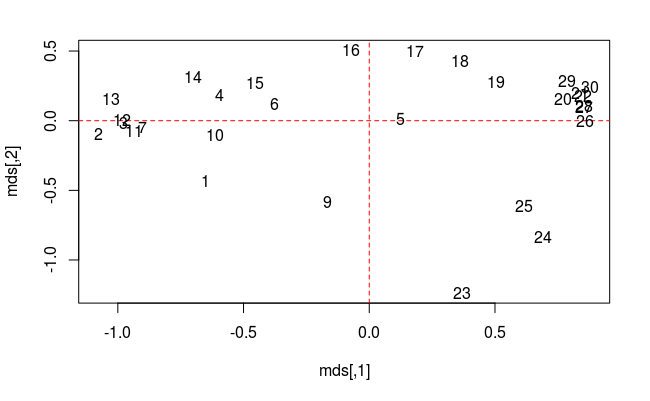

```r
abline(v = 0, col = "red", lty = 2)
text(mds[,1], mds[,2], labels = row.names(peces.perfil))
```

### nMDS

```r
peces <- read.csv2("peces.csv", row.names = 1)
sumEsp  <- apply(peces,1,sum)
peces   <- peces[sumEsp!=0,]
require(vegan)
peces.perfil <- decostand(peces, method = "normalize")
mat_dist <- dist(peces.perfil, method = "minkowski", p = 1/3)
print(mat_dist)
```

```
             1           2           3           4           5           6           7           9
2    11.277923
3    24.396166    5.144579
4   136.642143   63.686838   37.578332
5   417.235145  407.424089  399.973315  280.309993
6   247.254359  161.500267  115.361353   86.481289  241.094158
7    37.762409   14.779360   16.809063   73.208578  368.626035   89.704459
9    90.426484   67.431567  113.292446  186.553314  315.040862  220.402706  109.784208
10   93.355680   48.971249   56.030138  103.771646  276.310942  104.889295   32.130348  139.251561
11   61.628072   40.165985   52.069600  166.197245  453.767565  291.576364   54.400825  171.804575
12   66.794399   27.782106   41.068761  128.691115  599.641426  245.147683   20.986309  157.816810
13   71.338729   36.129811   49.423584  229.104362  747.278948  421.161832   83.211561  255.316235
14  241.342063  144.495084  135.810470  210.193947  826.854341  364.390230  165.039463  406.539486
15  375.997453  273.111645  340.466297  360.411886  672.488199  339.970461  243.433876  404.046438
16  957.352022  782.124391  801.331881  729.080071  740.858338  643.231159  767.916493  848.140607
17 1951.222791 1678.330758 1665.840804 1430.509736 1613.933936 1342.135864 1598.472950 1703.861281
18 2375.530339 2193.158505 2118.844807 1867.572443 1914.750778 1701.589150 2094.174844 1975.157279
19 2419.703575 2117.992654 2140.778037 2054.771834 1808.874098 1865.716656 2055.158998 1608.167657
20 2434.966881 2640.526730 2553.932847 2330.808533 1687.229611 1825.162319 2458.542666 1909.032506
21 2710.097683 3051.214855 2986.011752 2390.560100 1999.304652 2331.557239 2756.584351 2337.157360
22 2529.499546 3152.489528 3070.509221 2577.486485 2159.175474 2199.134109 2973.872358 2406.729633
23   39.943048  116.763599  157.179982  337.250832  452.070003  364.326638  149.685491   59.395393
24  228.146659  435.480428  529.248915  719.087687  924.968689  729.331640  508.434569  326.172789
25  253.304115  473.929078  455.375467  542.838067  465.386260  512.003484  427.684828  396.499614
26 2058.868823 2558.899428 2491.818032 2257.399191 1731.245449 1917.530141 2396.585202 1911.619214
27 2310.209913 2889.138056 2841.199118 2569.463347 2111.714635 2198.957681 2639.285418 2218.958613
28 2426.102351 3031.816653 2952.797510 2652.592737 2216.934108 1889.367550 2737.493297 2303.387043
29 3263.562622 3712.188183 3652.449535 2956.391564 2694.604200 2916.497120 3474.277269 3088.617232
30 2366.694410 3239.023848 3159.089024 2563.939895 2227.772163 2386.745644 2954.104971 2613.002595
            10          11          12          13          14          15          16          17
2
3
4
5
6
7
9
10
11  113.753118
12  111.154597   23.757193
```

[output cut: 61 more lines]

```
16
17
18
19
20
21
22
23
24
25
26
27  372.331702
28  452.803346  341.753748
29 1062.206121  698.068939  789.558094
30  825.847492  706.563907  383.698694  808.054338
```

```r
require(MASS)
nMDS <- isoMDS(mat_dist)
plot(nMDS$points[,1], nMDS$points[,2], type = "n")
abline(h = 0, col = "red", lty = 2)
```

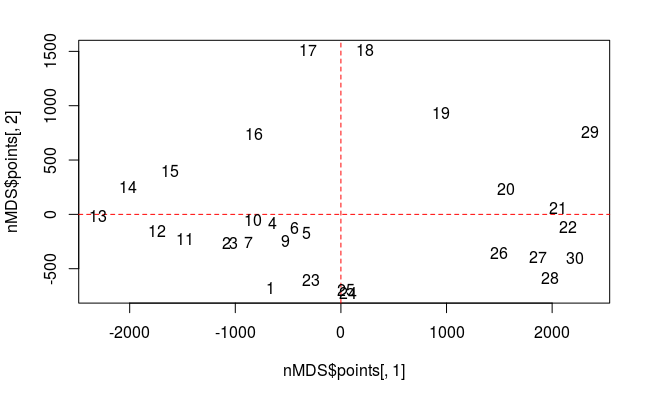

```r
abline(v = 0, col = "red", lty = 2)
text(nMDS$points[,1], nMDS$points[,2], labels = row.names(peces.perfil))
```

## Análisis de correspondencia (CA).

- MDS: Escalamiento multidmensional.
- PCoA: Análisis de coordenadas principales,
- CCA: Análisis de correspondencia canónico.
- CVA: Análisis de variable canónico.
- ANOSIM: Análisis de similitud.

```r
t1 <- read.csv2("tablaCont.csv", row.names = 1)
t1
```

|  | Cluster | PCA | MDS | PCoA | CCA | RDA | MANOVA | Mantel | ANOSIM | CVA |
| --- | --- | --- | --- | --- | --- | --- | --- | --- | --- | --- |
| Bacter | 553 | 434 | 51 | 5 | 37 | 21 | 15 | 5 | 10 | 13 |
| Microb | 82 | 72 | 7 | 2 | 4 | 4 | 2 | 3 | 1 | 2 |
| Plant | 1344 | 950 | 153 | 57 | 517 | 123 | 63 | 77 | 20 | 30 |
| Fung | 304 | 153 | 16 | 6 | 48 | 16 | 5 | 6 | 1 | 8 |
| Fish | 441 | 493 | 143 | 4 | 198 | 40 | 53 | 42 | 34 | 18 |
| Bird | 176 | 88 | 23 | 3 | 91 | 15 | 9 | 18 | 2 | 4 |
| Insect | 346 | 87 | 39 | 5 | 73 | 28 | 22 | 19 | 7 | 11 |

```r
margin.table(as.matrix(t1), 1)
```

```
Bacter Microb  Plant   Fung   Fish   Bird Insect
  1144    179   3334    563   1466    429    637
```

```r
margin.table(as.matrix(t1), 2)
```

```
Cluster     PCA     MDS    PCoA     CCA     RDA  MANOVA  Mantel  ANOSIM     CVA
   3246    2277     432      82     968     247     169     170      75      86
```

```r
chi1 <- chisq.test(t1)
```

```
Chi-squared approximation may be incorrect
```

```r
print(chi1)
```

```
    Pearson's Chi-squared test

data:  t1
X-squared = 578.16, df = 54, p-value < 2.2e-16
```

```r
print(chi1$observed)
```

```
       Cluster PCA MDS PCoA CCA RDA MANOVA Mantel ANOSIM CVA
Bacter     553 434  51    5  37  21     15      5     10  13
Microb      82  72   7    2   4   4      2      3      1   2
Plant     1344 950 153   57 517 123     63     77     20  30
Fung       304 153  16    6  48  16      5      6      1   8
Fish       441 493 143    4 198  40     53     42     34  18
Bird       176  88  23    3  91  15      9     18      2   4
Insect     346  87  39    5  73  28     22     19      7  11
```

```r
print(chi1$expected)
```

```
          Cluster       PCA        MDS      PCoA       CCA        RDA    MANOVA    Mantel    ANOSIM
Bacter  479.02786 336.02786  63.752322 12.101135 142.85243  36.450980 24.940144 25.087719 11.068111
Microb   74.95279  52.57779   9.975232  1.893447  22.35191   5.703431  3.902348  3.925439  1.731811
Plant  1396.04799 979.29799 185.795666 35.266770 416.31992 106.230392 72.683953 73.114035 32.256192
Fung    235.74536 165.37036  31.374613  5.955366  70.30237  17.938725 12.273865 12.346491  5.446981
Fish    613.85913 430.60913  81.696594 15.507224 183.06089  46.710784 31.960010 32.149123 14.183437
Bird    179.63545 126.01045  23.907121  4.537926  53.56966  13.669118  9.352554  9.407895  4.150542
Insect  266.73142 187.10642  35.498452  6.738132  79.54283  20.296569 13.887126 13.969298  6.162926
             CVA
Bacter 12.691434
Microb  1.985810
Plant  36.987100
Fung    6.245872
Fish   16.263674
Bird    4.759288
Insect  7.066821
```

```r
require(ca)
ca_t1 <- ca(t1)
ca_t1
```

```
 Principal inertias (eigenvalues):
           1        2        3        4        5        6
Value      0.035233 0.026746 0.011064 0.001164 0.000318 5.6e-05
Percentage 47.24%   35.86%   14.83%   1.56%    0.43%    0.08%


 Rows:
           Bacter    Microb     Plant     Fung      Fish      Bird    Insect
Mass     0.147575  0.023091  0.430083 0.072626  0.189112  0.055341  0.082172
ChiDist  0.364326  0.379370  0.130142 0.289552  0.329517  0.332658  0.376355
Inertia  0.019588  0.003323  0.007284 0.006089  0.020534  0.006124  0.011639
Dim. 1   1.841903  1.814691 -0.334880 1.253003 -0.910201 -1.358911 -0.162620
Dim. 2  -0.689812 -0.717055  0.437299 0.993077 -1.680987  1.065769  1.424732


 Columns:
         Cluster       PCA       MDS      PCoA       CCA       RDA    MANOVA    Mantel    ANOSIM      CVA
Mass    0.418731  0.293731  0.055728  0.010578  0.124871  0.031863  0.021801  0.021930  0.009675 0.011094
ChiDist 0.180789  0.221392  0.382311  0.574617  0.397353  0.237501  0.414914  0.436890  0.708188 0.224016
Inertia 0.013686  0.014397  0.008145  0.003493  0.019716  0.001797  0.003753  0.004186  0.004852 0.000557
Dim. 1  0.658768  0.517444 -1.138329 -0.471807 -1.944623 -0.788318 -1.501268 -2.174671 -1.421668 0.244303
Dim. 2  0.731977 -1.059702 -1.666058  2.207099  0.717044  1.014040 -0.992172  0.348263 -3.499596 0.024122
```

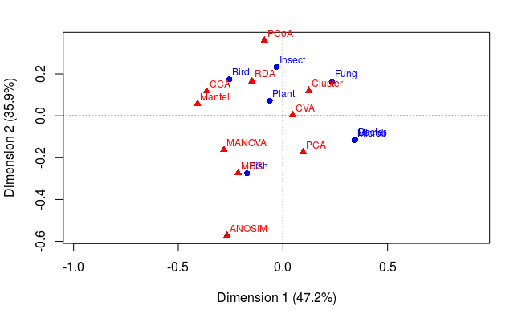

```r
plot(ca_t1)
```

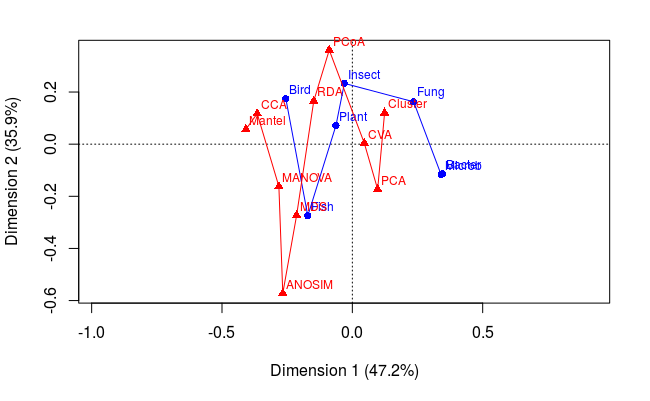

```r
plot(ca_t1, lines = TRUE)
```

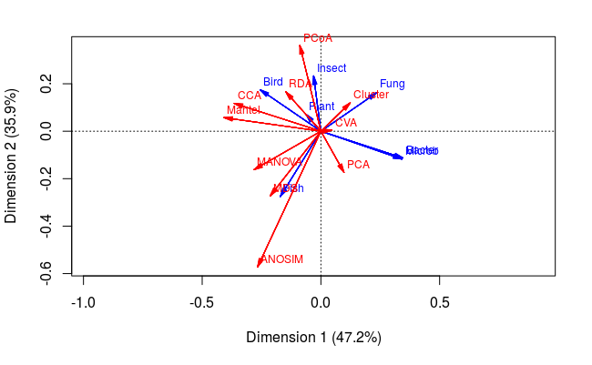

```r
plot(ca_t1, arrows = c(TRUE, TRUE))
```

## Análisis de correspondencia sin tendencia DCA.

```r
ejemplo1 <- read.csv2("ejemplo1_sitio.csv", row.names = 1)
row.names(ejemplo1) <- paste("Sitio", row.names(ejemplo1))
ejemplo1
```

|  | SP1 | SP2 | SP3 | SP4 | SP5 | SP6 | SP7 | SP8 | SP9 | SP10 | SP11 | SP12 | SP13 | SP14 | SP15 | SP16 | SP17 | SP18 | SP19 | SP20 |
| --- | --- | --- | --- | --- | --- | --- | --- | --- | --- | --- | --- | --- | --- | --- | --- | --- | --- | --- | --- | --- |
| Sitio 1 | 1 | 1 | 1 | 0 | 0 | 0 | 0 | 0 | 0 | 0 | 0 | 0 | 0 | 0 | 0 | 0 | 0 | 0 | 0 | 0 |
| Sitio 2 | 1 | 1 | 1 | 1 | 0 | 0 | 0 | 0 | 0 | 0 | 0 | 0 | 0 | 0 | 0 | 0 | 0 | 0 | 0 | 0 |
| Sitio 3 | 1 | 1 | 1 | 1 | 1 | 0 | 0 | 0 | 0 | 0 | 0 | 0 | 0 | 0 | 0 | 0 | 0 | 0 | 0 | 0 |
| Sitio 4 | 0 | 1 | 1 | 1 | 1 | 1 | 0 | 0 | 0 | 0 | 0 | 0 | 0 | 0 | 0 | 0 | 0 | 0 | 0 | 0 |
| Sitio 5 | 0 | 0 | 1 | 1 | 1 | 1 | 1 | 0 | 0 | 0 | 0 | 0 | 0 | 0 | 0 | 0 | 0 | 0 | 0 | 0 |
| Sitio 6 | 0 | 0 | 0 | 1 | 1 | 1 | 1 | 1 | 0 | 0 | 0 | 0 | 0 | 0 | 0 | 0 | 0 | 0 | 0 | 0 |
| Sitio 7 | 0 | 0 | 0 | 0 | 1 | 1 | 1 | 1 | 1 | 0 | 0 | 0 | 0 | 0 | 0 | 0 | 0 | 0 | 0 | 0 |
| Sitio 8 | 0 | 0 | 0 | 0 | 0 | 1 | 1 | 1 | 1 | 1 | 0 | 0 | 0 | 0 | 0 | 0 | 0 | 0 | 0 | 0 |
| Sitio 9 | 0 | 0 | 0 | 0 | 0 | 0 | 1 | 1 | 1 | 1 | 1 | 0 | 0 | 0 | 0 | 0 | 0 | 0 | 0 | 0 |
| Sitio 10 | 0 | 0 | 0 | 0 | 0 | 0 | 0 | 1 | 1 | 1 | 1 | 1 | 0 | 0 | 0 | 0 | 0 | 0 | 0 | 0 |

[output cut: 10 more lines]

```r
require(ca)
ca1 <- ca(ejemplo1)
ca1
```

```
 Principal inertias (eigenvalues):
           1        2       3        4        5        6        7        8        9        10
Value      0.945428 0.79626 0.590795 0.377372 0.198258 0.078079 0.057411 0.056247 0.041075 0.038788
Percentage 28.59%   24.08%  17.86%   11.41%   5.99%    2.36%    1.74%    1.7%     1.24%    1.17%
           11       12       13       14       15       16       17       18       19
Value      0.036979 0.024534 0.019418 0.017685 0.017089 0.006671 0.002179 0.001904 0.001052
Percentage 1.12%    0.74%    0.59%    0.53%    0.52%    0.2%     0.07%    0.06%    0.03%


 Rows:
          Sitio 1   Sitio 2   Sitio 3   Sitio 4   Sitio 5   Sitio 6   Sitio 7   Sitio 8   Sitio 9  Sitio 10
Mass     0.031915  0.042553  0.053191  0.053191  0.053191  0.053191  0.053191  0.053191  0.053191  0.053191
ChiDist  2.679829  2.185654  1.857238  1.716974  1.661325  1.661325  1.661325  1.661325  1.661325  1.661325
Inertia  0.229196  0.203280  0.183475  0.156809  0.146809  0.146809  0.146809  0.146809  0.146809  0.146809
Dim. 1  -1.426828 -1.391228 -1.343991 -1.248889 -1.123087 -0.964471 -0.779625 -0.572853 -0.350233 -0.117831
Dim. 2   1.465127  1.319301  1.137720  0.786881  0.367102 -0.100200 -0.553615 -0.947228 -1.236105 -1.389072
         Sitio 11  Sitio 12  Sitio 13  Sitio 14  Sitio 15 Sitio 16 Sitio 17 Sitio 18 Sitio 19 Sitio 20
Mass     0.053191  0.053191  0.053191  0.053191  0.053191 0.053191 0.053191 0.053191 0.042553 0.031915
ChiDist  1.661325  1.661325  1.661325  1.661325  1.661325 1.661325 1.716974 1.857238 2.185654 2.679829
Inertia  0.146809  0.146809  0.146809  0.146809  0.146809 0.146809 0.156809 0.183475 0.203280 0.229196
Dim. 1   0.117831  0.350233  0.572853  0.779625  0.964471 1.123087 1.248889 1.343991 1.391228 1.426828
Dim. 2  -1.389072 -1.236105 -0.947228 -0.553615 -0.100200 0.367102 0.786881 1.137720 1.319301 1.465127


 Columns:
              SP1       SP2       SP3       SP4       SP5       SP6       SP7       SP8       SP9      SP10
Mass     0.031915  0.042553  0.053191  0.053191  0.053191  0.053191  0.053191  0.053191  0.053191  0.053191
ChiDist  2.679829  2.185654  1.857238  1.716974  1.661325  1.661325  1.661325  1.661325  1.661325  1.661325
Inertia  0.229196  0.203280  0.183475  0.156809  0.146809  0.146809  0.146809  0.146809  0.146809  0.146809
Dim. 1  -1.426828 -1.391228 -1.343991 -1.248889 -1.123087 -0.964471 -0.779625 -0.572853 -0.350233 -0.117831
Dim. 2   1.465127  1.319301  1.137720  0.786881  0.367102 -0.100200 -0.553615 -0.947228 -1.236105 -1.389072
             SP11      SP12      SP13      SP14      SP15     SP16     SP17     SP18     SP19     SP20
Mass     0.053191  0.053191  0.053191  0.053191  0.053191 0.053191 0.053191 0.053191 0.042553 0.031915
ChiDist  1.661325  1.661325  1.661325  1.661325  1.661325 1.661325 1.716974 1.857238 2.185654 2.679829
Inertia  0.146809  0.146809  0.146809  0.146809  0.146809 0.146809 0.156809 0.183475 0.203280 0.229196
Dim. 1   0.117831  0.350233  0.572853  0.779625  0.964471 1.123087 1.248889 1.343991 1.391228 1.426828
Dim. 2  -1.389072 -1.236105 -0.947228 -0.553615 -0.100200 0.367102 0.786881 1.137720 1.319301 1.465127
```

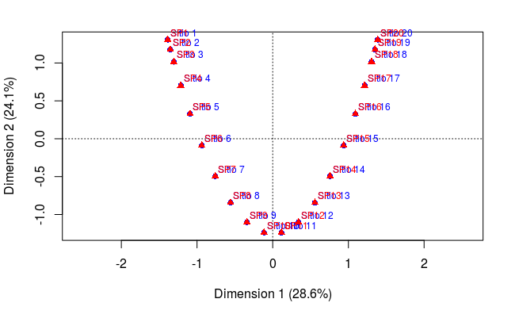

```r
plot(ca1)
```

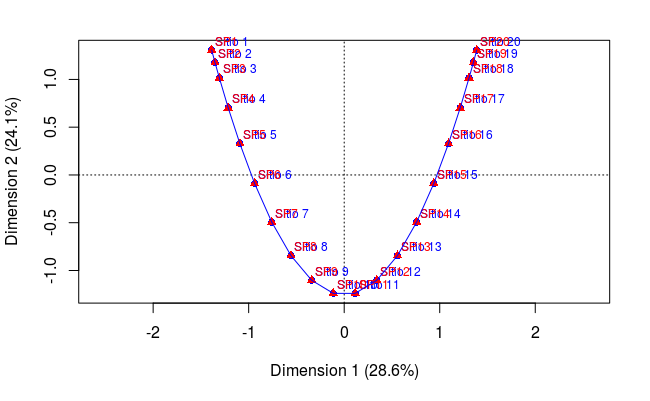

```r
plot(ca1, lines = c(TRUE, FALSE))
```

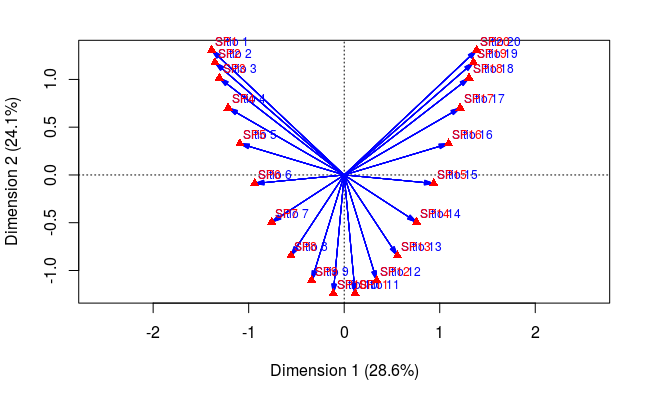

```r
plot(ca1, arrows = c(TRUE, FALSE))
```

```r
require(vegan)
dca1 <- decorana(ejemplo1)
dca1
```

```
Call:
decorana(veg = ejemplo1)

Detrended correspondence analysis with 26 segments.
Rescaling of axes with 4 iterations.

                   DCA1    DCA2    DCA3    DCA4
Eigenvalues      0.9351 0.23818 0.11471 0.05417
Decorana values  0.9454 0.06092 0.04539 0.02980
Axis lengths    11.0826 1.85490 1.28126 0.98343
```

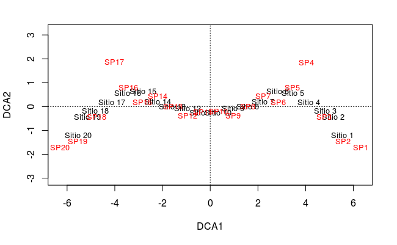

```r
plot(dca1)
```

## Análisis de redundancia

```r
peces   <- read.csv2("peces.csv", row.names = 1)
ambient <- read.csv2("ambientales.csv",enc="latin1",row.names=1)
sumEsp  <- apply(peces,1,sum)
peces   <- peces[sumEsp!=0,]
ambient <- ambient[sumEsp!=0,]
require(vegan)
peces.hell <- decostand(peces, "hell")
pca <- rda(peces.hell)
print(summary(pca))
```

```
Call:
rda(X = peces.hell)

Partitioning of variance:
              Inertia Proportion
Total          0.5025          1
Unconstrained  0.5025          1

Eigenvalues, and their contribution to the variance

Importance of components:
                         PC1     PC2     PC3     PC4     PC5     PC6     PC7     PC8      PC9     PC10
Eigenvalue            0.2580 0.06424 0.04632 0.03850 0.02197 0.01675 0.01472 0.01156 0.006936 0.006019
Proportion Explained  0.5133 0.12784 0.09218 0.07662 0.04371 0.03334 0.02930 0.02300 0.013800 0.011980
Cumulative Proportion 0.5133 0.64118 0.73337 0.80999 0.85370 0.88704 0.91634 0.93934 0.953140 0.965120
                          PC11     PC12     PC13     PC14     PC15     PC16      PC17      PC18      PC19
Eigenvalue            0.004412 0.002982 0.002713 0.001835 0.001455 0.001118 0.0008309 0.0005415 0.0004755
Proportion Explained  0.008780 0.005930 0.005400 0.003650 0.002890 0.002220 0.0016500 0.0010800 0.0009500
Cumulative Proportion 0.973900 0.979840 0.985240 0.988890 0.991780 0.994010 0.9956600 0.9967400 0.9976900
                          PC20      PC21      PC22      PC23      PC24     PC25      PC26      PC27
Eigenvalue            0.000368 0.0002765 0.0002253 0.0001429 7.618e-05 4.99e-05 1.526e-05 9.118e-06
Proportion Explained  0.000730 0.0005500 0.0004500 0.0002800 1.500e-04 1.00e-04 3.000e-05 2.000e-05
Cumulative Proportion 0.998420 0.9989700 0.9994200 0.9997000 9.999e-01 1.00e+00 1.000e+00 1.000e+00

Scaling 2 for species and site scores
* Species are scaled proportional to eigenvalues
* Sites are unscaled: weighted dispersion equal on all dimensions
* General scaling constant of scores:  1.93676


Species scores

          PC1      PC2       PC3        PC4        PC5       PC6
Cogo  0.17336  0.08295 -0.064963  0.2539861 -0.0285801  0.019057
Satr  0.64860  0.01162 -0.261994 -0.1606020 -0.0745819 -0.088616
Phph  0.51810  0.14773  0.165304  0.0241017  0.1012928  0.104748
Neba  0.38606  0.16615  0.242995 -0.0275216  0.1258011  0.048299
Thth  0.16893  0.06274 -0.096143  0.2426514  0.0140574  0.062117
Teso  0.07786  0.14644 -0.031402  0.2339394 -0.1032338 -0.040810
Chna -0.18491  0.04901 -0.045107  0.0199377  0.0687305  0.009650
```

[output cut: 39 more lines]

```
16  0.077024  0.47455  0.17116  0.34361 -0.570434 -0.572740
17 -0.053860  0.42290  0.02810  0.42376 -0.059203 -0.586419
18 -0.135418  0.37780  0.03233  0.39706 -0.007199 -0.347064
19 -0.269281  0.30751  0.18022  0.09354  0.178657 -0.016299
20 -0.378830  0.19764  0.04939 -0.03438  0.157660 -0.056696
21 -0.409369  0.22888 -0.08401 -0.12823  0.152787  0.096105
22 -0.443679  0.17698 -0.13708 -0.13152  0.103294  0.030004
23 -0.242292 -1.11711  0.15254  0.40512  0.045573 -0.576778
24 -0.358333 -0.83372 -0.17314  0.27200  0.181192  0.347231
25 -0.325288 -0.61983  0.10487  0.01059 -1.034438  0.750325
26 -0.441703  0.02111 -0.13742 -0.14346  0.200775  0.244356
27 -0.444529  0.12735 -0.15915 -0.14112  0.179240  0.123487
28 -0.446407  0.12774 -0.18830 -0.15467  0.239617  0.117101
29 -0.355788  0.28044 -0.28006 -0.02003  0.110181  0.079568
30 -0.467578  0.20086 -0.29797 -0.21269  0.065512  0.003276
```

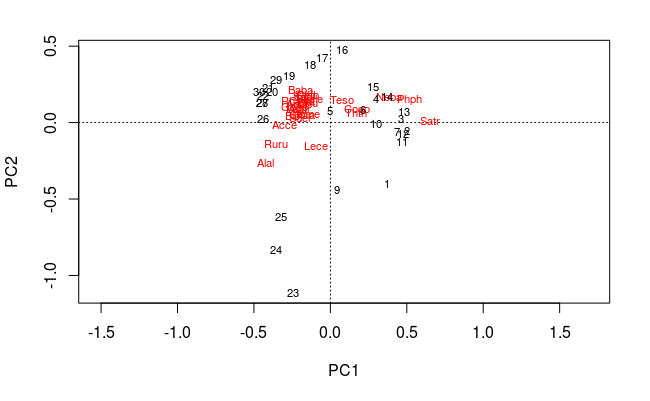

```r
plot(pca)
```

```r
rda1 <- rda(peces.hell ~ das, data = ambient)
print(summary(rda1))
```

```
Call:
rda(formula = peces.hell ~ das, data = ambient)

Partitioning of variance:
              Inertia Proportion
Total          0.5025     1.0000
Constrained    0.1958     0.3897
Unconstrained  0.3067     0.6103

Eigenvalues, and their contribution to the variance

Importance of components:
                        RDA1     PC1     PC2     PC3     PC4     PC5     PC6     PC7      PC8      PC9
Eigenvalue            0.1958 0.09117 0.06422 0.04311 0.02416 0.02106 0.01481 0.01254 0.009112 0.006351
Proportion Explained  0.3897 0.18142 0.12779 0.08580 0.04808 0.04191 0.02948 0.02496 0.018130 0.012640
Cumulative Proportion 0.3897 0.57115 0.69894 0.78473 0.83282 0.87473 0.90421 0.92917 0.947300 0.959940
                          PC10     PC11     PC12     PC13     PC14     PC15      PC16      PC17    PC18
Eigenvalue            0.005495 0.003709 0.002727 0.001898 0.001581 0.001325 0.0008844 0.0006854 0.00051
Proportion Explained  0.010940 0.007380 0.005430 0.003780 0.003150 0.002640 0.0017600 0.0013600 0.00101
Cumulative Proportion 0.970880 0.978260 0.983680 0.987460 0.990600 0.993240 0.9950000 0.9963600 0.99738
                           PC19      PC20     PC21      PC22      PC23      PC24      PC25      PC26
Eigenvalue            0.0004486 0.0002837 0.000226 0.0001584 9.257e-05 5.608e-05 3.792e-05 9.552e-06
Proportion Explained  0.0008900 0.0005600 0.000450 0.0003200 1.800e-04 1.100e-04 8.000e-05 2.000e-05
Cumulative Proportion 0.9982700 0.9988400 0.999290 0.9996000 9.998e-01 9.999e-01 1.000e+00 1.000e+00
                           PC27
Eigenvalue            3.924e-06
Proportion Explained  1.000e-05
Cumulative Proportion 1.000e+00

Accumulated constrained eigenvalues
Importance of components:
                        RDA1
Eigenvalue            0.1958
Proportion Explained  1.0000
Cumulative Proportion 1.0000

Scaling 2 for species and site scores
* Species are scaled proportional to eigenvalues
* Sites are unscaled: weighted dispersion equal on all dimensions
* General scaling constant of scores:  1.93676
```

[output cut: 91 more lines]

```
22  0.26551  0.327608  0.183949  0.229166  0.02125 -0.12546
23  0.29260  0.034710 -1.118655 -0.358632  0.32228 -0.33338
24  0.31995  0.080491 -0.838217 -0.009696  0.10633 -0.20429
25  0.35440  0.113298 -0.617354 -0.107446  0.19297  1.20923
26  0.43355  0.139969  0.021783  0.187543 -0.26562 -0.02284
27  0.47378  0.093350  0.126264  0.197870 -0.24491 -0.02795
28  0.53032  0.024389  0.124019  0.213270 -0.33913 -0.03695
29  0.60212 -0.232392  0.266901  0.180625 -0.23607  0.04984
30  0.68364 -0.123176  0.191332  0.310080 -0.31820  0.13401


Biplot scores for constraining variables

    RDA1 PC1 PC2 PC3 PC4 PC5
das    1   0   0   0   0   0
```

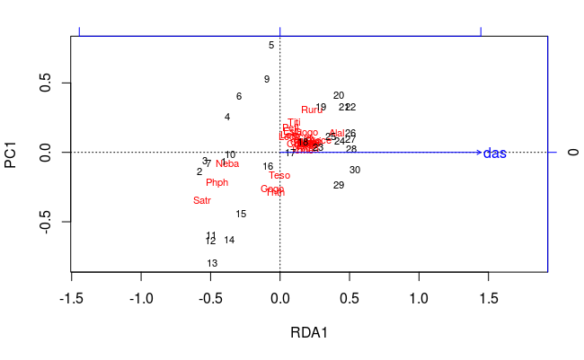

```r
plot(rda1)
```

```r
rda2 <- rda(peces.hell ~ ., data = ambient)
print(summary(rda2))
```

```
Call:
rda(formula = peces.hell ~ das + alt + slo + flo + pH + har +      pho + nit + amm + oxy + bdo, data = ambient)

Partitioning of variance:
              Inertia Proportion
Total          0.5025     1.0000
Constrained    0.3676     0.7314
Unconstrained  0.1350     0.2686

Eigenvalues, and their contribution to the variance

Importance of components:
                        RDA1    RDA2    RDA3    RDA4     RDA5     RDA6     RDA7     RDA8     RDA9     RDA10
Eigenvalue            0.2302 0.05347 0.03396 0.02762 0.006804 0.006271 0.003154 0.003017 0.001417 0.0008703
Proportion Explained  0.4581 0.10640 0.06758 0.05496 0.013540 0.012480 0.006280 0.006000 0.002820 0.0017300
Cumulative Proportion 0.4581 0.56451 0.63208 0.68704 0.700580 0.713060 0.719340 0.725340 0.728160 0.7298900
                          RDA11     PC1     PC2     PC3     PC4      PC5      PC6      PC7      PC8
Eigenvalue            0.0007768 0.04383 0.02270 0.01774 0.01413 0.009321 0.008515 0.005219 0.004581
Proportion Explained  0.0015500 0.08722 0.04518 0.03529 0.02811 0.018550 0.016940 0.010390 0.009120
Cumulative Proportion 0.7314400 0.81865 0.86384 0.89913 0.92724 0.945790 0.962730 0.973120 0.982240
                           PC9     PC10     PC11      PC12      PC13      PC14     PC15      PC16      PC17
Eigenvalue            0.002958 0.002013 0.001342 0.0009585 0.0007297 0.0003818 0.000334 0.0001299 7.886e-05
Proportion Explained  0.005890 0.004010 0.002670 0.0019100 0.0014500 0.0007600 0.000660 0.0002600 1.600e-04
Cumulative Proportion 0.988130 0.992130 0.994800 0.9967100 0.9981600 0.9989200 0.999580 0.9998400 1.000e+00

Accumulated constrained eigenvalues
Importance of components:
                        RDA1    RDA2    RDA3    RDA4     RDA5     RDA6     RDA7     RDA8     RDA9     RDA10
Eigenvalue            0.2302 0.05347 0.03396 0.02762 0.006804 0.006271 0.003154 0.003017 0.001417 0.0008703
Proportion Explained  0.6263 0.14547 0.09239 0.07513 0.018510 0.017060 0.008580 0.008210 0.003850 0.0023700
Cumulative Proportion 0.6263 0.77178 0.86417 0.93930 0.957810 0.974870 0.983460 0.991660 0.995520 0.9978900
                          RDA11
Eigenvalue            0.0007768
Proportion Explained  0.0021100
Cumulative Proportion 1.0000000

Scaling 2 for species and site scores
* Species are scaled proportional to eigenvalues
* Sites are unscaled: weighted dispersion equal on all dimensions
* General scaling constant of scores:  1.93676
```

[output cut: 101 more lines]

```

Biplot scores for constraining variables

       RDA1     RDA2     RDA3     RDA4     RDA5     RDA6
das -0.9128  0.12530 -0.14564  0.28559 -0.14025 -0.08596
alt  0.8174 -0.19940  0.42653 -0.31363  0.04070  0.04191
slo  0.7304 -0.18160  0.44131  0.12857 -0.03275  0.05724
flo -0.7734  0.22945 -0.11776  0.35275 -0.20906 -0.20090
pH   0.1032  0.17963 -0.23622  0.15717 -0.27998 -0.00646
har -0.5651  0.06594 -0.58956  0.05411 -0.38278 -0.21829
pho -0.4885 -0.66510 -0.22158  0.20580  0.19624 -0.37929
nit -0.7699 -0.21306 -0.25074  0.19239  0.30094 -0.31772
amm -0.4700 -0.70062 -0.19662  0.17917  0.34014 -0.29055
oxy  0.7593  0.57745 -0.03543  0.21067  0.03237  0.15692
bdo -0.5124 -0.80242 -0.19822  0.12204  0.05668 -0.05770
```

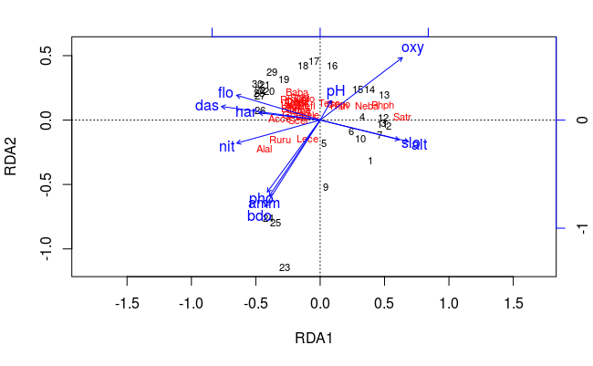

```r
plot(rda2)
```

## Análisis de correspondencia canónico

```r
peces   <- read.csv2("peces.csv", row.names = 1)
ambient <- read.csv2("ambientales.csv",enc="latin1",row.names=1)
sumEsp  <- apply(peces,1,sum)
peces   <- peces[sumEsp!=0,]
ambient <- ambient[sumEsp!=0,]
require(vegan)
cca1 <- cca(peces)
print(summary(cca1))
```

```
Call:
cca(X = peces)

Partitioning of mean squared contingency coefficient:
              Inertia Proportion
Total           1.167          1
Unconstrained   1.167          1

Eigenvalues, and their contribution to the mean squared contingency coefficient

Importance of components:
                        CA1    CA2     CA3     CA4     CA5     CA6     CA7     CA8     CA9    CA10    CA11
Eigenvalue            0.601 0.1444 0.10729 0.08337 0.05158 0.04185 0.03389 0.02883 0.01684 0.01083 0.01014
Proportion Explained  0.515 0.1237 0.09195 0.07145 0.04420 0.03586 0.02904 0.02470 0.01443 0.00928 0.00869
Cumulative Proportion 0.515 0.6388 0.73069 0.80214 0.84634 0.88220 0.91124 0.93594 0.95038 0.95965 0.96835
                          CA12     CA13     CA14     CA15     CA16     CA17     CA18     CA19     CA20
Eigenvalue            0.007886 0.006123 0.004867 0.004606 0.003844 0.003067 0.001823 0.001642 0.001295
Proportion Explained  0.006760 0.005250 0.004170 0.003950 0.003290 0.002630 0.001560 0.001410 0.001110
Cumulative Proportion 0.975100 0.980350 0.984520 0.988470 0.991760 0.994390 0.995950 0.997360 0.998470
                           CA21      CA22      CA23      CA24      CA25      CA26
Eigenvalue            0.0008775 0.0004217 0.0002149 0.0001528 8.949e-05 2.695e-05
Proportion Explained  0.0007500 0.0003600 0.0001800 0.0001300 8.000e-05 2.000e-05
Cumulative Proportion 0.9992200 0.9995900 0.9997700 0.9999000 1.000e+00 1.000e+00

Scaling 2 for species and site scores
* Species are scaled proportional to eigenvalues
* Sites are unscaled: weighted dispersion equal on all dimensions


Species scores

          CA1       CA2      CA3       CA4       CA5       CA6
Cogo  1.50075 -1.410293  0.26049 -0.307203  0.271777 -0.003465
Satr  1.66167  0.444129  0.57571  0.166073 -0.261870 -0.326590
Phph  1.28545  0.285328 -0.04768  0.018126  0.043847  0.200732
Neba  0.98662  0.360900 -0.35265 -0.009021 -0.012231  0.253429
Thth  1.55554 -1.389752  0.80505 -0.468471  0.471301  0.225409
Teso  0.99709 -1.479902 -0.48035  0.079397 -0.105715 -0.332445
Chna -0.54916 -0.051534  0.01123 -0.096004 -0.382763  0.134807
Chto -0.18478 -0.437710 -0.57438  0.424267 -0.587150  0.091866
```

[output cut: 38 more lines]

```
16  0.70214 -1.501167 -1.9735888  0.98502 -0.93585 -1.27168
17  0.28775 -0.836803 -1.2259108  0.73302 -1.57036  0.57315
18  0.05299 -0.647950 -0.9234228  0.35770 -0.95401  0.77738
19 -0.20584 -0.007252 -1.0154343  0.07041 -1.03450  0.51442
20 -0.57879  0.042849 -0.3660551 -0.15019 -0.61357  0.10115
21 -0.67320  0.038875  0.1194956  0.17256 -0.14686 -0.12018
22 -0.71933  0.014694  0.2204186  0.13598  0.09459 -0.02068
23 -0.70438  0.735398 -0.6546250 -6.61523 -2.49441 -1.73215
24 -0.83976  0.390120  0.5605295 -4.38864 -2.56916 -0.96702
25 -0.68476  0.418842 -0.2860819 -2.80336 -0.37540 -3.93791
26 -0.75808  0.210204  0.5894091 -0.70004 -0.01880 -0.10779
27 -0.75046  0.100869  0.5531191 -0.12946  0.29164  0.11280
28 -0.77878  0.088976  0.7379012  0.05204  0.40940  0.43236
29 -0.60815 -0.203235  0.5522726  0.43621  0.15010  0.25618
30 -0.80860 -0.019592  0.6686542  0.88136  0.52744  0.16456
```

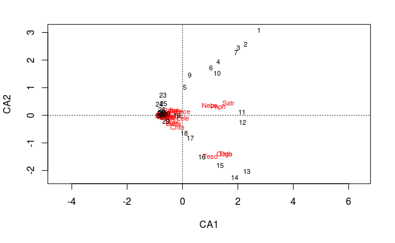

```r
plot(cca1)
```

```r
cca2 <- cca(peces, ambient)
print(summary(cca2))
```

```
Call:
cca(X = peces, Y = ambient)

Partitioning of mean squared contingency coefficient:
              Inertia Proportion
Total          1.1669     1.0000
Constrained    0.8377     0.7179
Unconstrained  0.3292     0.2821

Eigenvalues, and their contribution to the mean squared contingency coefficient

Importance of components:
                        CCA1   CCA2    CCA3    CCA4    CCA5    CCA6     CCA7    CCA8     CCA9   CCA10
Eigenvalue            0.5345 0.1227 0.06876 0.04886 0.02746 0.01295 0.009775 0.00545 0.003523 0.00217
Proportion Explained  0.4580 0.1052 0.05892 0.04187 0.02353 0.01110 0.008380 0.00467 0.003020 0.00186
Cumulative Proportion 0.4580 0.5632 0.62211 0.66399 0.68752 0.69862 0.707000 0.71167 0.714690 0.71655
                         CCA11     CA1     CA2     CA3     CA4     CA5     CA6     CA7      CA8      CA9
Eigenvalue            0.001596 0.10182 0.05329 0.05021 0.03452 0.03000 0.01456 0.01226 0.008865 0.007317
Proportion Explained  0.001370 0.08726 0.04567 0.04303 0.02958 0.02571 0.01248 0.01050 0.007600 0.006270
Cumulative Proportion 0.717910 0.80517 0.85084 0.89387 0.92345 0.94917 0.96165 0.97215 0.979740 0.986010
                         CA10     CA11     CA12     CA13     CA14      CA15      CA16      CA17
Eigenvalue            0.00457 0.003873 0.002968 0.002148 0.001493 0.0008308 0.0003886 4.723e-05
Proportion Explained  0.00392 0.003320 0.002540 0.001840 0.001280 0.0007100 0.0003300 4.000e-05
Cumulative Proportion 0.98993 0.993250 0.995790 0.997630 0.998910 0.9996300 0.9999600 1.000e+00

Accumulated constrained eigenvalues
Importance of components:
                        CCA1   CCA2    CCA3    CCA4    CCA5    CCA6     CCA7    CCA8     CCA9   CCA10
Eigenvalue            0.5345 0.1227 0.06876 0.04886 0.02746 0.01295 0.009775 0.00545 0.003523 0.00217
Proportion Explained  0.6380 0.1465 0.08207 0.05833 0.03278 0.01546 0.011670 0.00651 0.004210 0.00259
Cumulative Proportion 0.6380 0.7845 0.86656 0.92489 0.95767 0.97313 0.984790 0.99130 0.995500 0.99809
                         CCA11
Eigenvalue            0.001596
Proportion Explained  0.001910
Cumulative Proportion 1.000000

Scaling 2 for species and site scores
* Species are scaled proportional to eigenvalues
* Sites are unscaled: weighted dispersion equal on all dimensions

```

[output cut: 100 more lines]

```

Biplot scores for constraining variables

       CCA1     CCA2     CCA3     CCA4     CCA5      CCA6
das  0.8505  0.20713 -0.36616  0.21848 -0.05812 -0.122225
alt -0.7829 -0.51983  0.20652 -0.15363 -0.12246  0.003771
slo -0.6757 -0.38134  0.06041 -0.02902  0.06942  0.276108
flo  0.6712  0.19931 -0.47854  0.18667 -0.15433 -0.386319
pH  -0.1632  0.26541 -0.18504  0.17477 -0.34042  0.310417
har  0.5268  0.47813 -0.16715  0.19889 -0.43653 -0.386105
pho  0.4475 -0.02641  0.38275  0.58922  0.02700 -0.110983
nit  0.6805  0.19160  0.18329  0.15906  0.25741  0.115838
amm  0.4378 -0.08809  0.53506  0.47050  0.21034 -0.174471
oxy -0.7854  0.36744 -0.27958 -0.29226  0.23381 -0.052042
bdo  0.4819 -0.16869  0.50336  0.63234 -0.05626 -0.025082
```

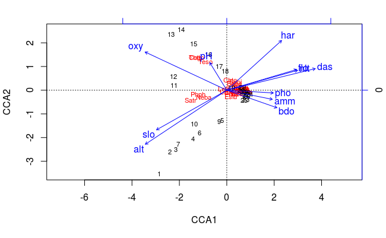

```r
plot(cca2)
```